# Part II - (Ford GoBike - Exploration and Data Findings Communication)

## by Anas saleh basalamah

## Investigation Overview

Bay Wheels (previously known as Ford GoBike) is a nearby public motorcycle sharing gadget within the San Francisco Bay vicinity, California. Bay Wheels is the primary nearby and big-scale bicycle sharing system deployed in California and at the West Coast of the united states with nearly 500,000 rides for the reason that release in 2017 and had about 10,000 annual subscribers as of January 2018. This exploration and visualization examine basically focuses on locating the bike usage sample and consumer dependancy traits from the 12-month ride journeys information in 2018.

## Dataset Overview

The dataset used for this exploratory evaluation includes monthly character ride data from January 2018 to December 2018 in CSV layout masking the greater San Francisco Bay region, raw data is available here. Visualizations below are comprised of wrangled and cleaned information to facilitate exploration evaluation and assist find out utilization sample and rider traits.

### Trend over the Year for the trips

##### The carrier is really affected by the seasons, so the usage of the service decreases in iciness and will increase in other seasons..

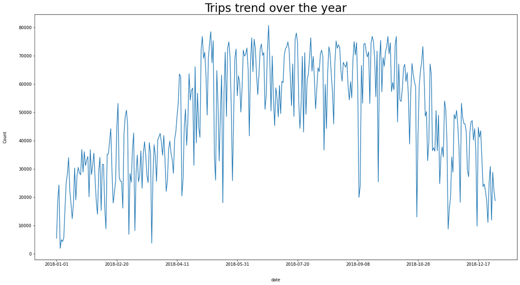

### Customer trip duration (min)

##### most of tripst under 1 hour and usually it's around 5 to 20 min ..

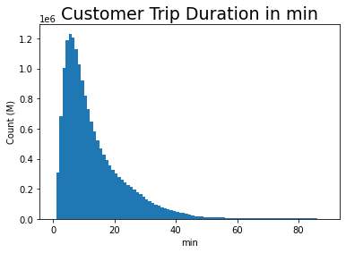

### Age Distribution

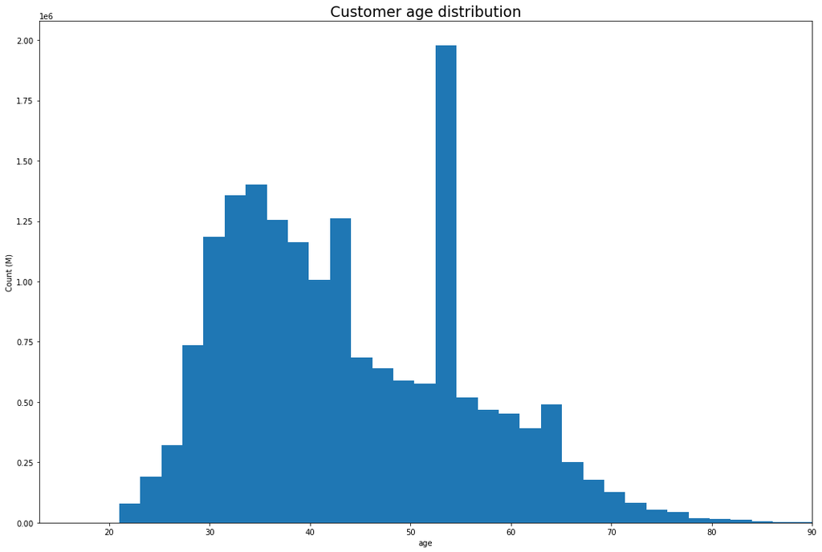